# R Notes 1-3 – R Practice Session

## Overview

Below are some basic problems to practice the concepts we have learned so far in R.

### Problem 1

Suppose we have the following discrete pmf for X:

[output not shown]

1. Create two vectors, one for $x$ and one for $f(x)$.

```r
# initialize vectors
x <- c(2, 4, 5, 8, 10, 11, 13)
f_x <- c(0.20, 0.13, 0.07, 0.21, 0.14, 0.09, 0.16)
```

2. Calculate the expected value of $X$ using your vectors.

```r
# E(X) = weighted average of x and f(x)
sum(x * f_x)
```

```
[1] 7.42
```

3. Calculate $P(X > 7)$ by subsetting the $f(x)$ vector with a logical test.

```r
# calculate probability -> add corresponding probabilities where X > 7
sum(f_x[x > 7])
```

```
[1] 0.6
```

4. Find the mode of $X$ by selecting the correct $x$ value based on a logic check of $f(x)$. NOTE: To check equality, use `==`.

```r
# find the X value with the highest probability
x[f_x == max(f_x)]
```

```
[1] 8
```

5. Plot the pmf of $X$.

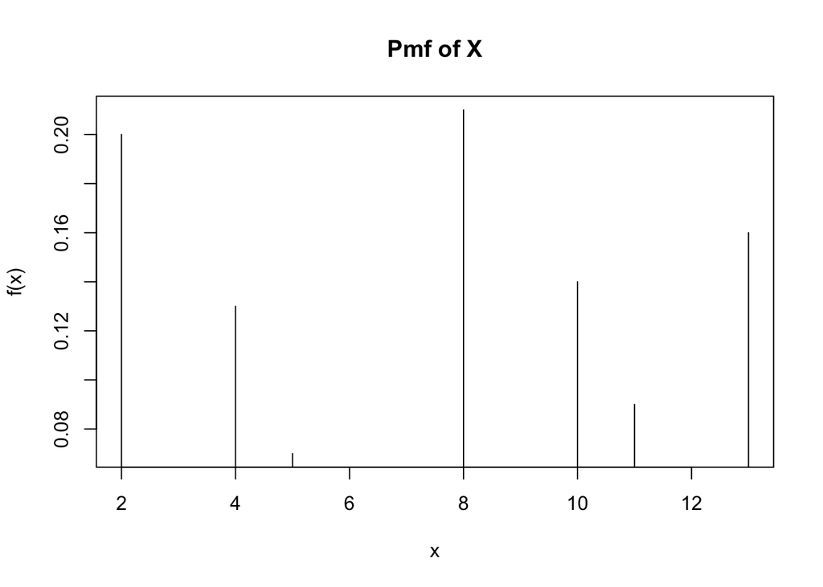

```r
# plot pmf
plot(x = x, y = f_x, type = "h", ylab = "f(x)", main = "Pmf of X")
```

### Problem 2

Generate a random sample from of size $n = 100$ from $\text{Gamma}(\text{shape } (\alpha) = 5, \text{rate } (\beta) = 2.5)$ and save it as a vector.

1. Count the number of values in your random sample that are greater than 2 using `sum()` on a logical check of your vector.

```r
# generate sample
data_sample <- rgamma(n = 100, shape = 5, rate = 2.5)

# count number of obs > 2
sum(data_sample > 2)
```

```
[1] 45
```

2. Calculate the sample probability of less than 1.5 using `mean()` on a logical check of your vector.

```r
# P(X < 1.5)
mean(data_sample < 1.5)
```

```
[1] 0.28
```

```r
# equivalent to
sum(data_sample < 1.5) / length(data_sample)
```

```
[1] 0.28
```

3. Search how to and compute the min, max, median, IQR, and range of your random sample.

```r
# all summary measures at once
summary(data_sample)
```

```
   Min. 1st Qu.  Median    Mean 3rd Qu.    Max.
 0.3638  1.4108  1.9443  2.0391  2.5970  4.6391
```

```r
# IQR = Q3 - Q1
quantile(data_sample, probs = 0.75) - quantile(data_sample, probs = 0.25)
```

```
     75%
1.186231
```

4. Create a boxplot of your random sample.

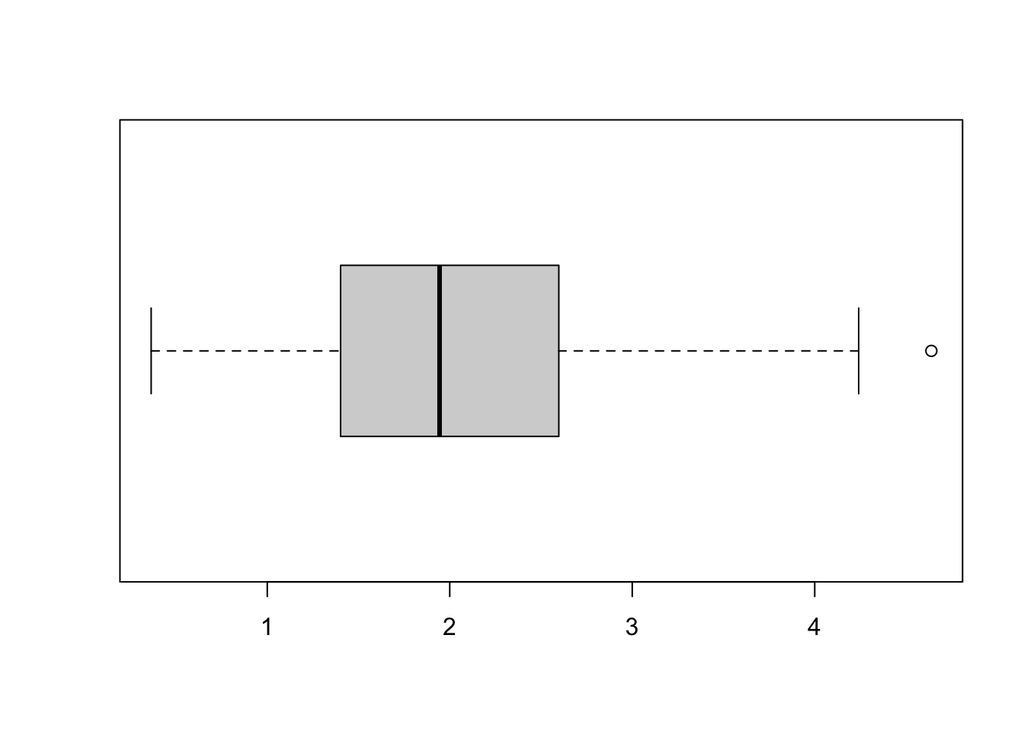

```r
# create boxplot
boxplot(data_sample, horizontal = TRUE)
```

5. Search how to extract any outliers based on your boxplot extract.

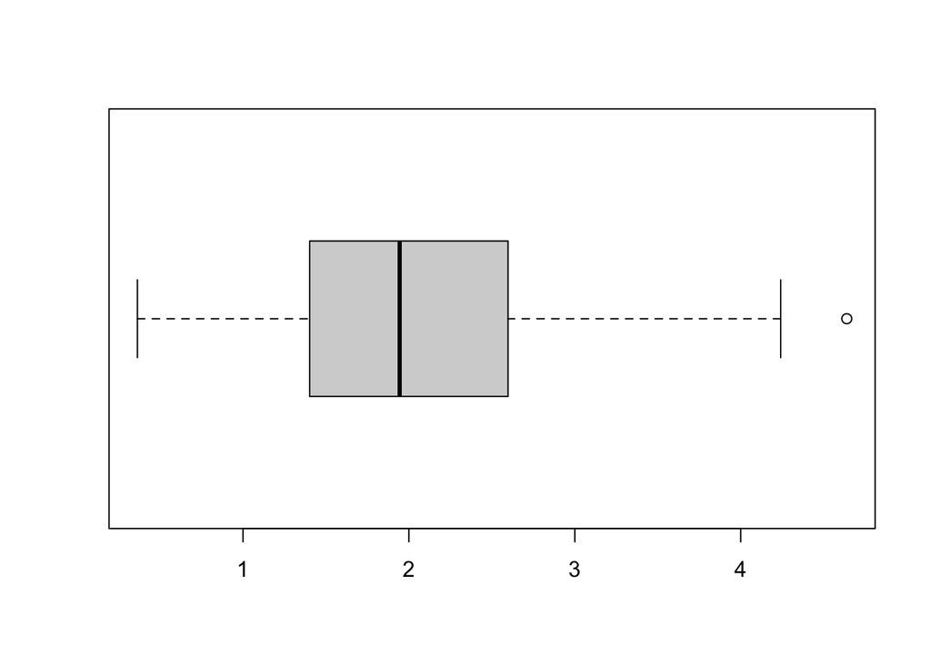

```
[1] 4.63905
```

```r
# extract outliers
boxplot(data_sample, horizontal = TRUE)$out
```